# Experimenting with transfer learning for visual categorization

### F1 score

And extract the [f1 score](https://scikit-learn.org/stable/modules/generated/sklearn.metrics.f1_score.html) for each networks :

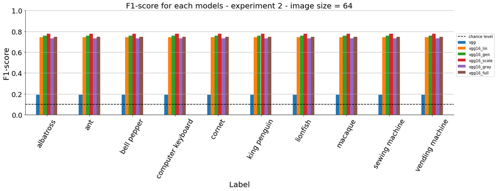

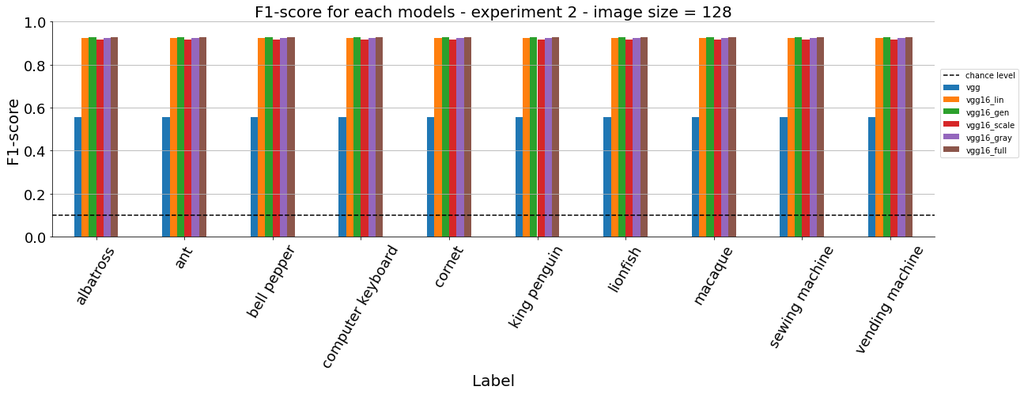

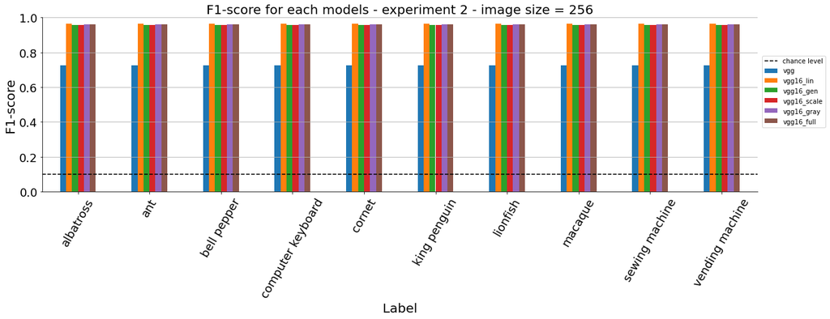

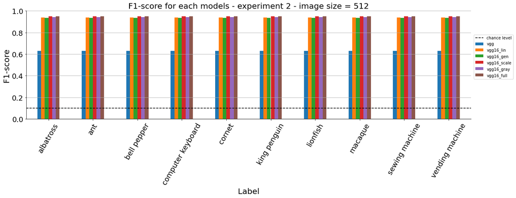

```python
for image_size in args.image_sizes:
    df_acc = pd.DataFrame({model_name: {subset_label: f1_score(df_downsample[(df_downsample['model']==model_name) & (df_downsample['image_size']==image_size)]["top_1"],
                                                               df_downsample[(df_downsample['model']==model_name) & (df_downsample['image_size']==image_size)]["label"],
                                                               average = 'micro')
                                        for subset_label in subset_labels}
                           for model_name in models_vgg.keys()})

    ax = df_acc.plot.bar(rot=60, figsize=(fig_width, fig_width//4), fontsize=18)
    ax.set_ylim(0, 1)
    ax.hlines(xmin=-.5, xmax=len(subset_labels)-.5, y=1/n_output, ls='--', ec='k', label='chance level')
    plt.legend(bbox_to_anchor=(1.1, .35), loc='lower right')
    ax.grid(which='both', axis='y')
    for side in ['top', 'right'] :ax.spines[side].set_visible(False)
    ax.set_title(f'F1-score for each models - experiment 2 - image size = {image_size}', size=20)
    ax.set_ylabel('F1-score', size=20)
    ax.set_xlabel('Label', size=20);
    plt.show();
```

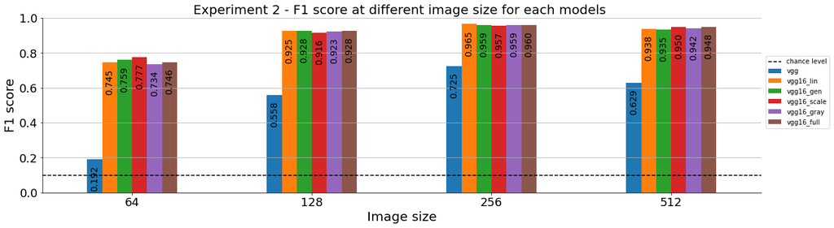

```python
df_acc = pd.DataFrame({model_name: {image_size: f1_score(df_downsample[(df_downsample['model']==model_name) & (df_downsample['image_size']==image_size)]["top_1"],
                                                         df_downsample[(df_downsample['model']==model_name) & (df_downsample['image_size']==image_size)]["label"],
                                                         average='micro')
                                    for image_size in args.image_sizes}
                       for model_name in models_vgg.keys()})

ax = df_acc.plot.bar(rot=0, figsize=(fig_width, fig_width//4), fontsize=18)
ax.set_ylim(0, 1)
ax.hlines(xmin=-.5, xmax=len(models_vgg.keys())-.5, y=1/n_output, ls='--', ec='k', label='chance level')
# https://matplotlib.org/stable/gallery/lines_bars_and_markers/bar_label_demo.html
for container in ax.containers: ax.bar_label(container, padding=-50, color='black', fontsize=14, fmt='%.3f', rotation=90)
plt.legend(bbox_to_anchor=(1.1, .35), loc='lower right')
ax.grid(which='both', axis='y')
for side in ['top', 'right'] :ax.spines[side].set_visible(False)
ax.set_title(f'Experiment 2 - F1 score at different image size for each models ', size=20)
ax.set_ylabel('F1 score', size=20)
ax.set_xlabel('Image size', size=20)
plt.show();
```

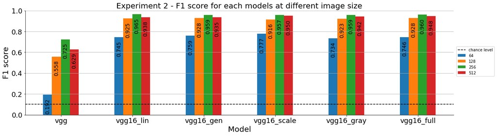

```python
ax = df_acc.T.plot.bar(rot=0, figsize=(fig_width, fig_width//4), fontsize=18)
ax.set_ylim(0, 1)
ax.hlines(xmin=-.5, xmax=len(models_vgg.keys())-.5, y=1/n_output, ls='--', ec='k', label='chance level')
# https://matplotlib.org/stable/gallery/lines_bars_and_markers/bar_label_demo.html
for container in ax.containers: ax.bar_label(container, padding=-50, color='black', fontsize=14, fmt='%.3f', rotation=90)
plt.legend(bbox_to_anchor=(1.1, .35), loc='lower right')
ax.grid(which='both', axis='y')
for side in ['top', 'right'] :ax.spines[side].set_visible(False)
ax.set_title(f'Experiment 2 - F1 score for each models at different image size', size=20)
ax.set_ylabel('F1 score', size=20)
ax.set_xlabel('Model', size=20)
plt.show();
```

### Computation time

A display of the differents computation time of each models on the same dataset for differents resolutions :

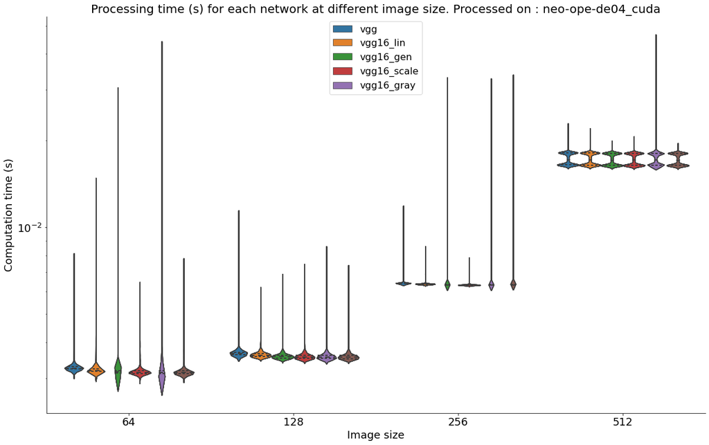

```python
fig, axs = plt.subplots(figsize=(fig_width, fig_width/phi))
for color, model_name in zip(colors, models_vgg.keys()):
    axs = sns.violinplot(x="image_size", y="time", data=df_downsample, inner="quartile", hue='model')
    axs.set_title('Processing time (s) for each network at different image size. Processed on : ' + args.HOST + '_' + str(df_downsample['device_type'][0]), size = 20)
    axs.set_ylabel('Computation time (s)', size=18)
    axs.set_xlabel('Image size', size=18)
    axs.set_yscale('log')
    axs.grid(which='both', axis='y')
    for side in ['top', 'right'] :axs.spines[side].set_visible(False)
h, l = axs.get_legend_handles_labels()
axs.legend(h[:5], l[:5], loc='upper center', fontsize=16);
```

### Categorization likelihood

Let's display the likelihood of each models on the same dataset for differents resolutions. Here accuracies are displayed as a violin plot to allow a better representation of the models.

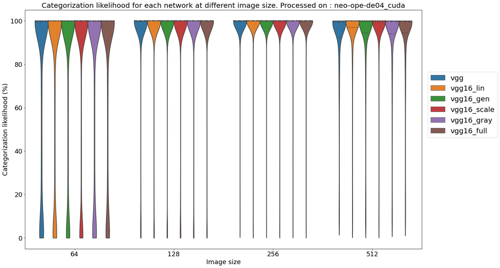

```python
fig, axs = plt.subplots(figsize=(fig_width, fig_width/phi))
axs = sns.violinplot(x="image_size", y="likelihood", data=df_downsample, inner="quartile", hue='model', cut = 0, scale = 'width')
axs.set_title('Categorization likelihood for each network at different image size. Processed on : ' + args.HOST + '_' + str(df_downsample['device_type'][0]), size=20)
axs.set_ylabel('Categorization likelihood (%)', size=18)
axs.set_xlabel('Image size', size=18)
axs.legend(bbox_to_anchor=(1.2, .45), loc='lower right', fontsize = 20)
ax.grid(which='both', axis='y')
for side in ['top', 'right'] :ax.spines[side].set_visible(False)
h, l = axs.get_legend_handles_labels()
```

### Summary

Mean f1 score

```python
for model_name in models_vgg.keys():
    pprint(f'Benchmarking model {model_name}')
    for image_size in args.image_sizes:
        df_ = df_downsample[(df_downsample['model']==model_name) & (df_downsample['image_size']==image_size)]
        mean_f1_score = f1_score(df_["top_1"] , df_["label"] , average = 'micro')
        print(f'For size {image_size}, the mean f1 score = {mean_f1_score*100:.4f} %' )
```

```
----------------------
Benchmarking model vgg
----------------------
For size 64, the mean f1 score = 19.1884 %
For size 128, the mean f1 score = 55.7866 %
For size 256, the mean f1 score = 72.4699 %
For size 512, the mean f1 score = 62.8758 %
----------------------------
Benchmarking model vgg16_lin
----------------------------
For size 64, the mean f1 score = 74.4739 %
For size 128, the mean f1 score = 92.5100 %
For size 256, the mean f1 score = 96.5431 %
For size 512, the mean f1 score = 93.7876 %
----------------------------
Benchmarking model vgg16_gen
----------------------------
For size 64, the mean f1 score = 75.9269 %
For size 128, the mean f1 score = 92.8106 %
For size 256, the mean f1 score = 95.8918 %
For size 512, the mean f1 score = 93.4870 %
------------------------------
Benchmarking model vgg16_scale
------------------------------
For size 64, the mean f1 score = 77.6553 %
For size 128, the mean f1 score = 91.5581 %
For size 256, the mean f1 score = 95.6914 %
For size 512, the mean f1 score = 94.9649 %
-----------------------------
Benchmarking model vgg16_gray
-----------------------------
For size 64, the mean f1 score = 73.4469 %
For size 128, the mean f1 score = 92.3096 %
For size 256, the mean f1 score = 95.9168 %
For size 512, the mean f1 score = 94.2134 %
-----------------------------
Benchmarking model vgg16_full
-----------------------------
For size 64, the mean f1 score = 74.6493 %
For size 128, the mean f1 score = 92.8106 %
For size 256, the mean f1 score = 96.0421 %
For size 512, the mean f1 score = 94.8397 %
```

Mean categorization likelihood

```python
for model_name in models_vgg.keys():
    pprint(f'Benchmarking model {model_name}')
    for image_size in args.image_sizes:
        med_likelihood = np.mean(df_downsample[(df_downsample['model']==model_name) & (df_downsample['image_size']==image_size)]["likelihood"])
        print(f'For size {image_size}, the mean clasification likelihood = {med_likelihood:.5f} %' )
```

```
----------------------
Benchmarking model vgg
----------------------
For size 64, the mean clasification likelihood = 71.30679 %
For size 128, the mean clasification likelihood = 90.60969 %
For size 256, the mean clasification likelihood = 94.11937 %
For size 512, the mean clasification likelihood = 89.01307 %
----------------------------
Benchmarking model vgg16_lin
----------------------------
For size 64, the mean clasification likelihood = 73.72051 %
For size 128, the mean clasification likelihood = 92.13664 %
For size 256, the mean clasification likelihood = 95.78246 %
For size 512, the mean clasification likelihood = 91.08758 %
----------------------------
Benchmarking model vgg16_gen
----------------------------
For size 64, the mean clasification likelihood = 75.01264 %
For size 128, the mean clasification likelihood = 92.37035 %
For size 256, the mean clasification likelihood = 95.28685 %
For size 512, the mean clasification likelihood = 89.37263 %
------------------------------
Benchmarking model vgg16_scale
------------------------------
For size 64, the mean clasification likelihood = 77.01949 %
For size 128, the mean clasification likelihood = 91.17951 %
For size 256, the mean clasification likelihood = 95.13552 %
For size 512, the mean clasification likelihood = 92.68679 %
-----------------------------
Benchmarking model vgg16_gray
-----------------------------
For size 64, the mean clasification likelihood = 72.49181 %
For size 128, the mean clasification likelihood = 91.75696 %
For size 256, the mean clasification likelihood = 95.12077 %
For size 512, the mean clasification likelihood = 89.65246 %
-----------------------------
Benchmarking model vgg16_full
-----------------------------
For size 64, the mean clasification likelihood = 73.41183 %
For size 128, the mean clasification likelihood = 92.25266 %
For size 256, the mean clasification likelihood = 95.37998 %
For size 512, the mean clasification likelihood = 90.24870 %
```

Mean computation time

```python
for model_name in models_vgg.keys():
    pprint(f'Benchmarking model {model_name}')
    for image_size in args.image_sizes:
        med_likelihood = np.mean(df_downsample[(df_downsample['model']==model_name) & (df_downsample['image_size']==image_size)]["time"])
        print(f'For size {image_size}, the mean computation time = {med_likelihood:.3f} s' )
```

```
----------------------
Benchmarking model vgg
----------------------
For size 64, the mean computation time = 0.003 s
For size 128, the mean computation time = 0.004 s
For size 256, the mean computation time = 0.006 s
For size 512, the mean computation time = 0.017 s
----------------------------
Benchmarking model vgg16_lin
----------------------------
For size 64, the mean computation time = 0.003 s
For size 128, the mean computation time = 0.004 s
For size 256, the mean computation time = 0.006 s
For size 512, the mean computation time = 0.017 s
----------------------------
Benchmarking model vgg16_gen
----------------------------
For size 64, the mean computation time = 0.003 s
For size 128, the mean computation time = 0.004 s
For size 256, the mean computation time = 0.006 s
For size 512, the mean computation time = 0.017 s
------------------------------
Benchmarking model vgg16_scale
------------------------------
For size 64, the mean computation time = 0.003 s
For size 128, the mean computation time = 0.004 s
For size 256, the mean computation time = 0.006 s
For size 512, the mean computation time = 0.017 s
-----------------------------
Benchmarking model vgg16_gray
-----------------------------
For size 64, the mean computation time = 0.003 s
For size 128, the mean computation time = 0.004 s
For size 256, the mean computation time = 0.006 s
For size 512, the mean computation time = 0.017 s
-----------------------------
Benchmarking model vgg16_full
-----------------------------
For size 64, the mean computation time = 0.003 s
For size 128, the mean computation time = 0.004 s
For size 256, the mean computation time = 0.006 s
For size 512, the mean computation time = 0.017 s
```

Mean frame per second

```python
for model_name in models_vgg.keys():
    pprint(f'Benchmarking model {model_name}')
    for image_size in args.image_sizes:
        med_likelihood = np.mean(df_downsample[(df_downsample['model']==model_name) & (df_downsample['image_size']==image_size)]["fps"])
        print(f'For size {image_size}, the mean fps = {med_likelihood:.3f} Hz' )
```

```
----------------------
Benchmarking model vgg
----------------------
For size 64, the mean fps = 304.122 Hz
For size 128, the mean fps = 271.853 Hz
For size 256, the mean fps = 155.893 Hz
For size 512, the mean fps = 57.927 Hz
----------------------------
Benchmarking model vgg16_lin
----------------------------
For size 64, the mean fps = 310.492 Hz
For size 128, the mean fps = 276.000 Hz
For size 256, the mean fps = 156.795 Hz
For size 512, the mean fps = 58.022 Hz
----------------------------
Benchmarking model vgg16_gen
----------------------------
For size 64, the mean fps = 314.709 Hz
For size 128, the mean fps = 279.379 Hz
For size 256, the mean fps = 157.803 Hz
For size 512, the mean fps = 58.190 Hz
------------------------------
Benchmarking model vgg16_scale
------------------------------
For size 64, the mean fps = 315.299 Hz
For size 128, the mean fps = 279.953 Hz
For size 256, the mean fps = 157.960 Hz
For size 512, the mean fps = 58.180 Hz
-----------------------------
Benchmarking model vgg16_gray
-----------------------------
For size 64, the mean fps = 315.056 Hz
For size 128, the mean fps = 280.027 Hz
For size 256, the mean fps = 157.838 Hz
For size 512, the mean fps = 58.159 Hz
-----------------------------
Benchmarking model vgg16_full
-----------------------------
For size 64, the mean fps = 316.148 Hz
For size 128, the mean fps = 280.455 Hz
For size 256, the mean fps = 157.872 Hz
For size 512, the mean fps = 58.186 Hz
```

## Experiment 3: Image processing and recognition on grayscale images

Again, another analysis of the robustness using the likelihood indicators but now with a grayscale transformation and compare them with the likelihood indicators from experiment 1.

```python
scriptname = 'experiment_grayscale.py'
```

```python
%%writefile {scriptname}

#import model's script and set the output file
from experiment_train import *
filename = f'results/{datetag}_results_3_{args.HOST}.json'
print(f'{filename=}')

def main():
    if os.path.isfile(filename):
        df_gray = pd.read_json(filename)
    else:
        i_trial = 0
        df_gray = pd.DataFrame([], columns=['model', 'likelihood', 'fps', 'time', 'label', 'i_label', 'i_image', 'filename', 'device_type', 'top_1'])
        # image preprocessing setting a grayscale output
        (dataset_sizes, dataloaders, image_datasets, data_transforms) = datasets_transforms(image_size=args.image_size, p=1, batch_size=1)

        # Displays the input image of the model
        for i_image, (data, label) in enumerate(dataloaders['test']):
            data, label = data.to(device), label.to(device)

            for model_name in models_vgg.keys():
                model = models_vgg[model_name]
                model = model.to(device)

                with torch.no_grad():
                    i_label_top = reverse_labels[image_datasets['test'].classes[label]]
                    tic = time.time()
                    out = model(data).squeeze(0)
                    if model_name == 'vgg' :
                        percentage = torch.nn.functional.softmax(out[args.subset_i_labels], dim=0) * 100
                        _, indices = torch.sort(out, descending=True)
                        top_1 = labels[indices[0]]
                        likelihood = percentage[reverse_subset_i_labels[i_label_top]].item()
                    else :
                        percentage = torch.nn.functional.softmax(out, dim=0) * 100
                        _, indices = torch.sort(out, descending=True)
                        top_1 = subset_labels[indices[0]]
                        likelihood = percentage[label].item()
                dt = time.time() - tic
                df_gray.loc[i_trial] = {'model':model_name, 'likelihood':likelihood, 'time':dt, 'fps': 1/dt,
                                   'label':labels[i_label_top], 'i_label':i_label_top,
                                   'i_image':i_image, 'filename':image_datasets['test'].imgs[i_image][0], 'device_type':device.type, 'top_1':str(top_1)}
                print(f'The {model_name} model get {labels[i_label_top]} at {likelihood:.2f} % confidence in {dt:.3f} seconds, best confidence for : {top_1}')
                i_trial += 1
        df_gray.to_json(filename)

main()
```

```
Overwriting experiment_grayscale.py
```

```python
%run -int {scriptname}
```

```
IPython CPU timings (estimated):
  User   :       0.18 s.
  System :       0.00 s.
Wall time:       0.18 s.
```

Collecting all the results, displaying all the data in a table

```python
filename = f'results/{datetag}_results_3_{args.HOST}.json'
df_gray = pd.read_json(filename)
df_gray
```

|  | model | likelihood | fps | time | label | i_label | i_image | filename | device_type | top_1 |
| --- | --- | --- | --- | --- | --- | --- | --- | --- | --- | --- |
| 0 | vgg | 99.161537 | 15.158363 | 0.065970 | albatross | 146 | 0 | data/test/albatross/0001096bb6acdc6c546229f243... | cuda | goose |
| 1 | vgg16_lin | 99.995735 | 142.707087 | 0.007007 | albatross | 146 | 0 | data/test/albatross/0001096bb6acdc6c546229f243... | cuda | albatross |
| 2 | vgg16_gen | 99.977547 | 143.951127 | 0.006947 | albatross | 146 | 0 | data/test/albatross/0001096bb6acdc6c546229f243... | cuda | albatross |
| 3 | vgg16_scale | 99.864014 | 142.001693 | 0.007042 | albatross | 146 | 0 | data/test/albatross/0001096bb6acdc6c546229f243... | cuda | albatross |
| 4 | vgg16_gray | 99.967918 | 132.467044 | 0.007549 | albatross | 146 | 0 | data/test/albatross/0001096bb6acdc6c546229f243... | cuda | albatross |
| ... | ... | ... | ... | ... | ... | ... | ... | ... | ... | ... |
| 23947 | vgg16_lin | 99.999252 | 156.387174 | 0.006394 | vending machine | 886 | 3991 | data/test/vending machine/ffe141944f70eaa5c09d... | cuda | vending machine |
| 23948 | vgg16_gen | 99.999962 | 157.769569 | 0.006338 | vending machine | 886 | 3991 | data/test/vending machine/ffe141944f70eaa5c09d... | cuda | vending machine |
| 23949 | vgg16_scale | 99.999855 | 157.757701 | 0.006339 | vending machine | 886 | 3991 | data/test/vending machine/ffe141944f70eaa5c09d... | cuda | vending machine |
| 23950 | vgg16_gray | 99.945679 | 157.219582 | 0.006361 | vending machine | 886 | 3991 | data/test/vending machine/ffe141944f70eaa5c09d... | cuda | vending machine |
| 23951 | vgg16_full | 99.989235 | 157.650968 | 0.006343 | vending machine | 886 | 3991 | data/test/vending machine/ffe141944f70eaa5c09d... | cuda | vending machine |

23952 rows × 10 columns

### Image display

The 64 **worsts** categorization likelihood, all models combined :

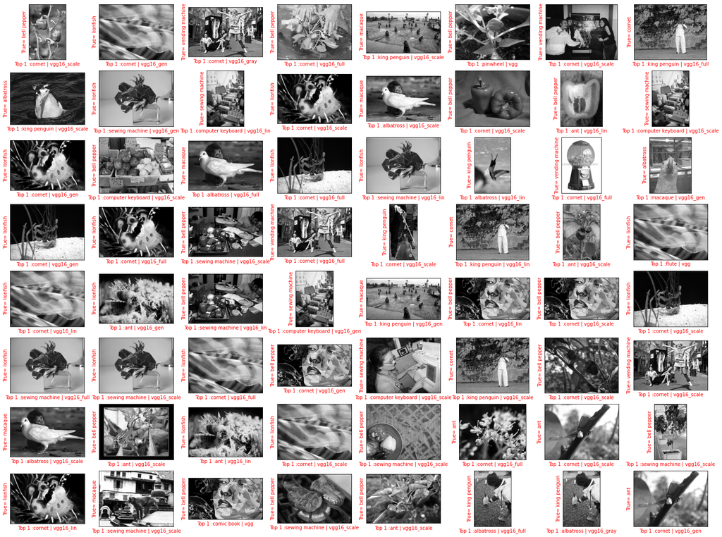

```python
import imageio
N_image_i = 8
N_image_j = 8
fig, axs = plt.subplots(N_image_i, N_image_j, figsize=(fig_width*1.3, fig_width))
for i_image, idx in enumerate(df_gray.sort_values(by=['likelihood'], ascending=True).head(N_image_i*N_image_j).index):
    ax = axs[i_image%N_image_i][i_image//N_image_i]
    ax.imshow(imageio.imread(image_datasets['test'].imgs[df_gray.loc[idx]['i_image']][0], pilmode="L"), cmap='gray')
    ax.set_xticks([])
    ax.set_yticks([])
    ax.set_xlabel('Top 1 :' + df_gray.loc[idx]['top_1'] + ' | ' + df_gray.loc[idx]['model'], color='r')
    label = df_gray.loc[idx]['label']
    ax.set_ylabel(f'True= {label}', color='r')
fig.set_facecolor(color='white')
```

### F1 score

Mean f1 score

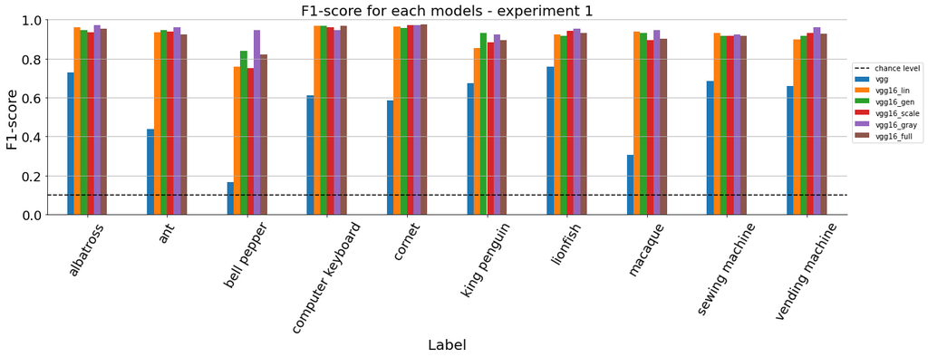

```python
df_f1_score = pd.DataFrame({model_name: {subset_label: f1_score(df_gray[(df_gray['model']==model_name) & (df_gray['label']==subset_label)]["top_1"],
                                                                df_gray[(df_gray['model']==model_name) & (df_gray['label']==subset_label)]["label"],
                                                                average='micro')
                                    for subset_label in subset_labels}
                       for model_name in models_vgg.keys()})

ax = df_f1_score.plot.bar(rot=60, figsize=(fig_width, fig_width//4), fontsize=18)
ax.set_ylim(0, 1)
ax.hlines(xmin=-.5, xmax=len(subset_labels)-.5, y=1/n_output, ls='--', ec='k', label='chance level')
plt.legend(bbox_to_anchor=(1.1, .35), loc='lower right')
ax.grid(which='both', axis='y')
for side in ['top', 'right'] :ax.spines[side].set_visible(False)
ax.set_title('F1-score for each models - experiment 1', size=20)
ax.set_ylabel('F1-score', size=20)
ax.set_xlabel('Label', size=20);
```

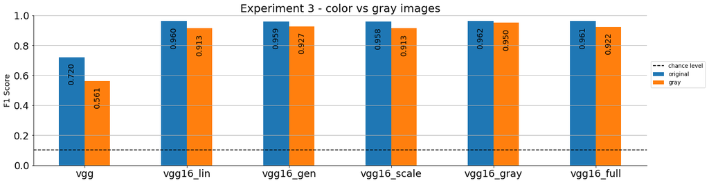

```python
from sklearn.metrics import accuracy_score, precision_score, f1_score
df_acc = pd.DataFrame({model_name: {label: f1_score(df_[(df_['model']==model_name)]["top_1"],
                                                               df_[(df_['model']==model_name)]["label"],
                                                   average='micro')
                                    for label, df_ in zip(['original', 'gray'], [df, df_gray])}
                       for model_name in models_vgg.keys()})

ax = df_acc.T.plot.bar(rot=0, figsize=(fig_width, fig_width//4), fontsize=18)
ax.set_ylim(0, 1)
ax.hlines(xmin=-.5, xmax=len(models_vgg.keys())-.5, y=1/n_output, ls='--', ec='k', label='chance level')
# https://matplotlib.org/stable/gallery/lines_bars_and_markers/bar_label_demo.html
for container in ax.containers: ax.bar_label(container, padding=-50, color='black', fontsize=14, fmt='%.3f', rotation=90)
plt.legend(bbox_to_anchor=(1.1, .5), loc='lower right')
ax.grid(which='both', axis='y')
for side in ['top', 'right'] :ax.spines[side].set_visible(False)
ax.set_title(f'Experiment 3 - color vs gray images', size=20)
ax.set_ylabel('F1 Score', size=14)
plt.show();
```

### Computation time

A display of the differents computation time of each models on the same dataset for a single resolution :

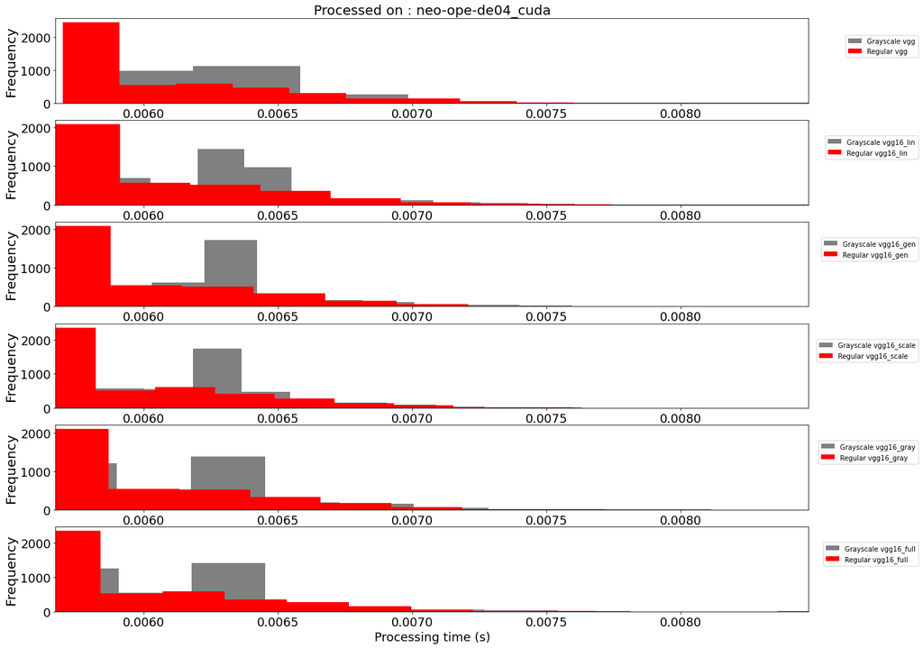

```python
fig, axs = plt.subplots(len(models_vgg.keys()), 1, figsize=(fig_width, fig_width*phi/2))
for color, df_, label, legend in zip(['gray', 'red'], [df_gray, df], ['black', 'color'], ['Grayscale', 'Regular']):
    for ax, model_name in zip(axs, models_vgg.keys()):
        ax.set_ylabel('Frequency', fontsize=20)
        df_[df_['model']==model_name]['time'].plot.hist(bins=150, lw=1, label=str(legend+ ' ' + model_name), ax=ax, color=color, density=True)
        ax.legend(loc='upper right', fontsize=20)
        ax.set_xlim(df_gray['time'].quantile(.01), df_gray['time'].quantile(.99))
        ax.legend(bbox_to_anchor=(1.15, .5), loc='lower right')
axs[-1].set_xlabel('Processing time (s)', size=18)
axs[0].set_title('Processed on : ' + args.HOST + '_' + str(df['device_type'][0]), size = 20);
```

### Categorization likelihood

Let's analyze the categorization likelihood of each models on the same dataset for color versus grayscale images. Here likelihood's are displayed as a violin plot to allow a better representation of the models.

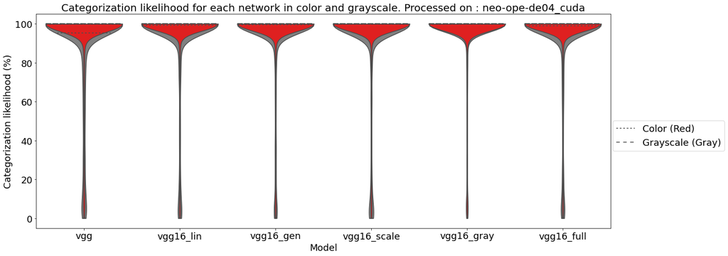

```python
import seaborn as sns

fig, axs = plt.subplots(figsize=(fig_width, fig_width/phi**2))
for color, df_, label in zip(['gray', 'red'], [df_gray, df], ['black', 'color']):
    axs = sns.violinplot(x="model", y="likelihood", data=df_, inner="quartile", cut=0, color=color, alpha=.5, scale = 'width', label = color)
ax.grid(which='both', axis='y')
for side in ['top', 'right'] :ax.spines[side].set_visible(False)
axs.set_title('Categorization likelihood for each network in color and grayscale. Processed on : ' + args.HOST + '_' + str(df_['device_type'][0]), size=20)
axs.set_ylabel('Categorization likelihood (%)', size=18)
axs.set_xlabel('Model', size=18)
fig.legend(['Color (Red)', 'Grayscale (Gray)'], bbox_to_anchor=(1.06, .45), fontsize=18,loc='center right');
```

### Summary

The F1 score for all networks are affected by the use of grayscale images, even the `VGG_Gray`, although the latter is the most robust. This result may originate from the fact that it was pre-trained on RGB images. However, the performance remains largely above the chance level, and this for all networks, which shows that, without colors, the networks can still discriminate the $10$ classes in most cases. For some images, this information is necessary for the discrimination, a need that can be partly compensated by transfer learning in the `VGG_Gray` network.

Mean F1 score

```python
for model_name in models_vgg.keys():
    mean_f1_score_orig = f1_score(df[df['model']==model_name]["top_1"] , df[df['model']==model_name]["label"], average='micro')
    mean_f1_score = f1_score(df_gray[df_gray['model']==model_name]["top_1"] , df_gray[df_gray['model']==model_name]["label"], average='micro')
    print(f'For the {model_name} model, the mean clasification likelihood = {mean_f1_score*100:.5f} % (color = {mean_f1_score_orig*100:.5f} % )' )
```

```
For the vgg model, the mean clasification likelihood = 56.11222 % (color = 71.96894 % )
For the vgg16_lin model, the mean clasification likelihood = 91.33267 % (color = 96.04208 % )
For the vgg16_gen model, the mean clasification likelihood = 92.71042 % (color = 95.86673 % )
For the vgg16_scale model, the mean clasification likelihood = 91.28257 % (color = 95.81663 % )
For the vgg16_gray model, the mean clasification likelihood = 95.04008 % (color = 96.16733 % )
For the vgg16_full model, the mean clasification likelihood = 92.18437 % (color = 96.14228 % )
```

Mean categorization likelihood

```python
for model_name in models_vgg.keys():
    med_likelihood_orig = np.mean(df[df['model']==model_name]["likelihood"])
    med_likelihood = np.mean(df_gray[df_gray['model']==model_name]["likelihood"])
    print(f'For the {model_name} model, the mean clasification likelihood = {med_likelihood:.5f} % (color = {med_likelihood_orig:.5f} % )' )
    print(stats.ttest_1samp(df_gray[df_gray['model']==model_name]["likelihood"], np.mean(df[df['model']==model_name]["likelihood"])))
```

```
For the vgg model, the mean clasification likelihood = 87.33926 % (color = 93.65200 % )
Ttest_1sampResult(statistic=-14.649980053455742, pvalue=2.2429526996649943e-47)
For the vgg16_lin model, the mean clasification likelihood = 90.26159 % (color = 95.44061 % )
Ttest_1sampResult(statistic=-12.95031355669835, pvalue=1.3259253690031956e-37)
For the vgg16_gen model, the mean clasification likelihood = 91.33653 % (color = 95.24963 % )
Ttest_1sampResult(statistic=-10.437591406415853, pvalue=3.5127506993701646e-25)
For the vgg16_scale model, the mean clasification likelihood = 90.04138 % (color = 95.21186 % )
Ttest_1sampResult(statistic=-12.394191316766264, pvalue=1.2100071819816907e-34)
For the vgg16_gray model, the mean clasification likelihood = 93.94850 % (color = 95.19329 % )
Ttest_1sampResult(statistic=-3.9455179894920955, pvalue=8.099664974423112e-05)
For the vgg16_full model, the mean clasification likelihood = 90.30311 % (color = 95.19237 % )
Ttest_1sampResult(statistic=-12.409216564045165, pvalue=1.0101014943635101e-34)
```

Mean computation time

```python
for model_name in models_vgg.keys():
    med_likelihood_orig = np.mean(df[df['model']==model_name]["time"])
    med_likelihood = np.mean(df_gray[df_gray['model']==model_name]["time"])
    print(f'For the {model_name} model, the mean computation time = {med_likelihood:.4f} s (color = {med_likelihood_orig:.4f} s )' )
```

```
For the vgg model, the mean computation time = 0.0064 s (color = 0.0061 s )
For the vgg16_lin model, the mean computation time = 0.0062 s (color = 0.0061 s )
For the vgg16_gen model, the mean computation time = 0.0062 s (color = 0.0060 s )
For the vgg16_scale model, the mean computation time = 0.0062 s (color = 0.0061 s )
For the vgg16_gray model, the mean computation time = 0.0062 s (color = 0.0061 s )
For the vgg16_full model, the mean computation time = 0.0062 s (color = 0.0061 s )
```

Mean frame per second

```python
for model_name in models_vgg.keys():
    med_likelihood_orig = np.mean(df[df['model']==model_name]["fps"])
    med_likelihood = np.mean(df_gray[df_gray['model']==model_name]["fps"])
    print(f'For the {model_name} model, the mean fps = {med_likelihood:.3f} Hz (color = {med_likelihood_orig:.3f} Hz )' )
```

```
For the vgg model, the mean fps = 158.050 Hz (color = 164.520 Hz )
For the vgg16_lin model, the mean fps = 161.456 Hz (color = 165.491 Hz )
For the vgg16_gen model, the mean fps = 162.464 Hz (color = 166.931 Hz )
For the vgg16_scale model, the mean fps = 162.417 Hz (color = 166.828 Hz )
For the vgg16_gray model, the mean fps = 162.607 Hz (color = 166.881 Hz )
For the vgg16_full model, the mean fps = 162.751 Hz (color = 167.084 Hz )
```

## Experiment 4: Image processing and recognition on contrasted images

Again, same likelihood indicators but now with a contrast filter.

```python
scriptname = 'experiment_contrast.py'
```

```python
%%writefile {scriptname}
#import model's script and set the output file
from experiment_train import *
filename = f'results/{datetag}_results_4_{args.HOST}.json'
print(f'{filename=}')

def main():
    if os.path.isfile(filename):
        df_contrast = pd.read_json(filename)
    else:
        i_trial = 0
        df_contrast = pd.DataFrame([], columns=['model', 'likelihood', 'fps', 'time', 'label', 'i_label', 'i_image', 'contrast', 'filename', 'device_type', 'top_1'])
        # image preprocessing
        for contrast in np.arange(1,110,10):
            (dataset_sizes, dataloaders, image_datasets, data_transforms) = datasets_transforms(c=contrast, batch_size=1)
            print(f'Contrast de {contrast=}')
            # Displays the input image of the model
            for i_image, (data, label) in enumerate(dataloaders['test']):
                data, label = data.to(device), label.to(device)

                for model_name in models_vgg.keys():
                    model = models_vgg[model_name]
                    model = model.to(device)

                    with torch.no_grad():
                        i_label_top = reverse_labels[image_datasets['test'].classes[label]]
                        tic = time.time()
                        out = model(data).squeeze(0)
                        _, indices = torch.sort(out, descending=True)
                        if model_name == 'vgg' : # our previous work
                            top_1 = labels[indices[0]]
                            percentage = torch.nn.functional.softmax(out[args.subset_i_labels], dim=0) * 100
                            likelihood = percentage[reverse_subset_i_labels[i_label_top]].item()
                        else :
                            top_1 = subset_labels[indices[0]]
                            percentage = torch.nn.functional.softmax(out, dim=0) * 100
                            likelihood = percentage[label].item()
                        dt = time.time() - tic
                    print(f'The {model_name} model get {labels[i_label_top]} at {likelihood:.2f} % confidence in {dt:.3f} seconds, best confidence for : {top_1}')
                    df_contrast.loc[i_trial] = {'model':model_name, 'likelihood':likelihood, 'time':dt, 'fps': 1/dt,
                                       'label':labels[i_label_top], 'i_label':i_label_top,
                                       'i_image':i_image, 'filename':image_datasets['test'].imgs[i_image][0], 'contrast': contrast, 'device_type':device.type, 'top_1':str(top_1)}
                    i_trial += 1

    df_contrast.to_json(filename)

main()
```

```
Overwriting experiment_contrast.py
```

```python
%run -int {scriptname}
```

```
Creating file results/2021-12-08_config_args.json
On date 2021-12-08 , Running benchmark on host neo-ope-de04  with device cuda
-------------------------------
List of Pre-selected classes :
-------------------------------
-> label 945 = bell pepper
id wordnet :  n02056570
-> label 513 = cornet
id wordnet :  n02058221
-> label 886 = vending machine
id wordnet :  n02219486
-> label 508 = computer keyboard
id wordnet :  n02487347
-> label 786 = sewing machine
id wordnet :  n02643566
-> label 310 = ant
id wordnet :  n03085013
-> label 373 = macaque
id wordnet :  n03110669
-> label 145 = king penguin
id wordnet :  n04179913
-> label 146 = albatross
id wordnet :  n04525305
-> label 396 = lionfish
id wordnet :  n07720875
Loaded 4002 images under test
Loaded 2088 images under val
Loaded 5331 images under train
Classes:  ['albatross', 'ant', 'bell pepper', 'computer keyboard', 'cornet', 'king penguin', 'lionfish', 'macaque', 'sewing machine', 'vending machine']
Loading pretrained model for.. vgg16_lin  from models/re-trained_vgg16_lin.pt
Loading pretrained model for.. vgg16_gen  from models/re-trained_vgg16_gen.pt
Loading pretrained model for.. vgg16_scale  from models/re-trained_vgg16_scale.pt
Loading pretrained model for.. vgg16_gray  from models/re-trained_vgg16_gray.pt
Loading pretrained model for.. vgg16_full  from models/re-trained_vgg16_full.pt
filename='results/2021-12-08_results_4_neo-ope-de04.json'

IPython CPU timings (estimated):
  User   :      28.94 s.
  System :      15.74 s.
Wall time:      18.33 s.
```

```python
filename = f'results/{datetag}_results_4_{args.HOST}.json'
df_contrast = pd.read_json(filename)
df_contrast
```

|  | model | likelihood | fps | time | label | i_label | i_image | contrast | filename | device_type | top_1 |
| --- | --- | --- | --- | --- | --- | --- | --- | --- | --- | --- | --- |
| 0 | vgg | 99.973885 | 20.847063 | 0.047968 | albatross | 146 | 0 | 1 | data/test/albatross/0001096bb6acdc6c546229f243... | cuda | albatross |
| 1 | vgg16_lin | 99.999916 | 147.318464 | 0.006788 | albatross | 146 | 0 | 1 | data/test/albatross/0001096bb6acdc6c546229f243... | cuda | albatross |
| 2 | vgg16_gen | 99.813889 | 149.444310 | 0.006691 | albatross | 146 | 0 | 1 | data/test/albatross/0001096bb6acdc6c546229f243... | cuda | albatross |
| 3 | vgg16_scale | 97.847305 | 153.071202 | 0.006533 | albatross | 146 | 0 | 1 | data/test/albatross/0001096bb6acdc6c546229f243... | cuda | albatross |
| 4 | vgg16_gray | 99.998985 | 147.743985 | 0.006768 | albatross | 146 | 0 | 1 | data/test/albatross/0001096bb6acdc6c546229f243... | cuda | albatross |
| ... | ... | ... | ... | ... | ... | ... | ... | ... | ... | ... | ... |
| 264127 | vgg16_lin | 95.563713 | 154.094713 | 0.006490 | vending machine | 886 | 4001 | 101 | data/test/vending machine/ffe141944f70eaa5c09d... | cuda | vending machine |
| 264128 | vgg16_gen | 99.999878 | 155.017334 | 0.006451 | vending machine | 886 | 4001 | 101 | data/test/vending machine/ffe141944f70eaa5c09d... | cuda | vending machine |
| 264129 | vgg16_scale | 100.000000 | 155.477036 | 0.006432 | vending machine | 886 | 4001 | 101 | data/test/vending machine/ffe141944f70eaa5c09d... | cuda | vending machine |
| 264130 | vgg16_gray | 99.967804 | 154.862797 | 0.006457 | vending machine | 886 | 4001 | 101 | data/test/vending machine/ffe141944f70eaa5c09d... | cuda | vending machine |
| 264131 | vgg16_full | 99.999870 | 155.800453 | 0.006418 | vending machine | 886 | 4001 | 101 | data/test/vending machine/ffe141944f70eaa5c09d... | cuda | vending machine |

264132 rows × 11 columns

### Image display

The 64 **worsts** categorization likelihood, all models combined :

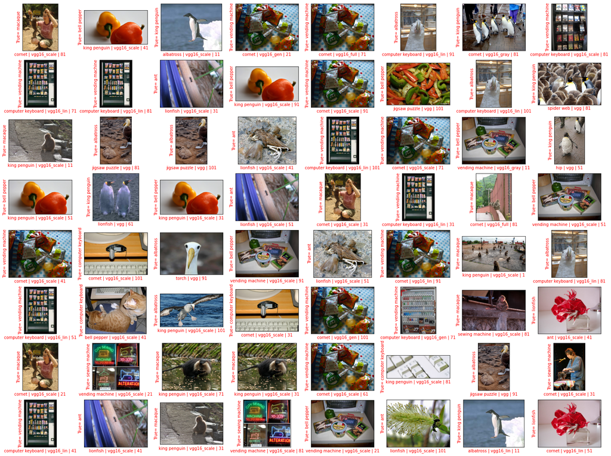

```python
import imageio
N_image_i = 8
N_image_j = 8
fig, axs = plt.subplots(N_image_i, N_image_j, figsize=(fig_width*1.3, fig_width))
for i_image, idx in enumerate(df_contrast.sort_values(by=['likelihood'], ascending=True).head(N_image_i*N_image_j).index):
    ax = axs[i_image%N_image_i][i_image//N_image_i]
    ax.imshow(imageio.imread(image_datasets['test'].imgs[df_contrast.loc[idx]['i_image']][0]))
    ax.set_xticks([])
    ax.set_yticks([])
    ax.set_xlabel(df_contrast.loc[idx]['top_1'] + ' | ' + df_contrast.loc[idx]['model'] + ' | ' + str(df_contrast.loc[idx]['contrast']), color='r')
    label = df_contrast.loc[idx]['label']
    ax.set_ylabel(f'True= {label}', color='r')
fig.set_facecolor(color='white')
```

### F1 score

And extract the [f1 score](https://scikit-learn.org/stable/modules/generated/sklearn.metrics.f1_score.html) for each networks :

```
-------------------------
Benchmarking contrast = 1
-------------------------
```

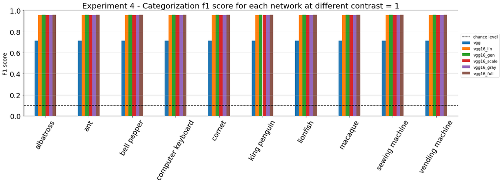

```
--------------------------
Benchmarking contrast = 11
--------------------------
```

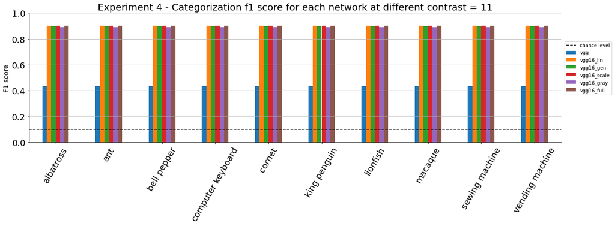

```
--------------------------
Benchmarking contrast = 21
--------------------------
```

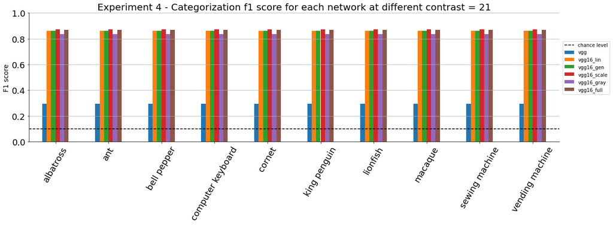

```
--------------------------
Benchmarking contrast = 31
--------------------------
```

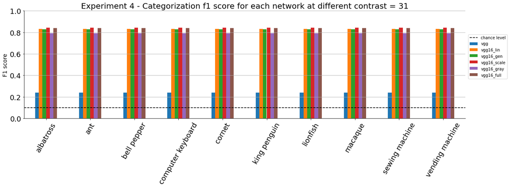

```
--------------------------
Benchmarking contrast = 41
--------------------------
```

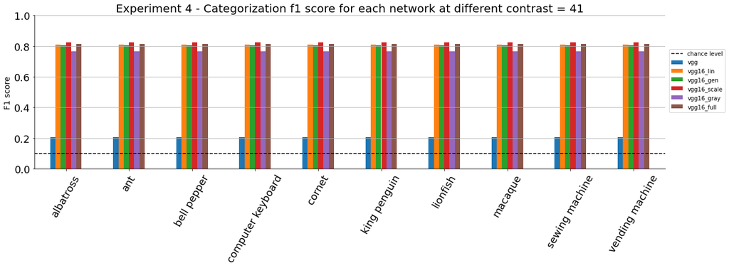

```
--------------------------
Benchmarking contrast = 51
--------------------------
```

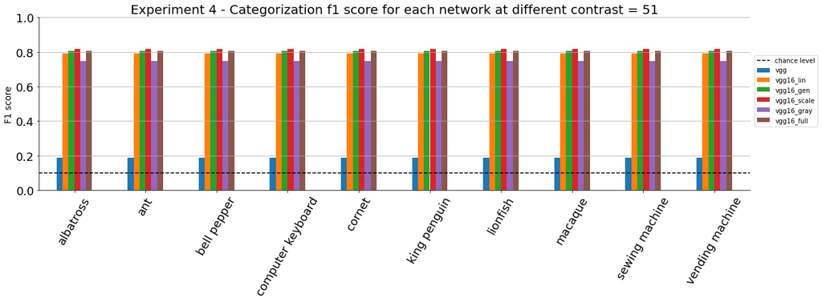

```
--------------------------
Benchmarking contrast = 61
--------------------------
```

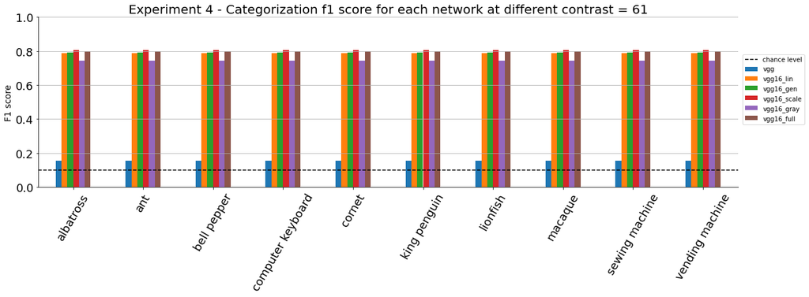

```
--------------------------
Benchmarking contrast = 71
--------------------------
```

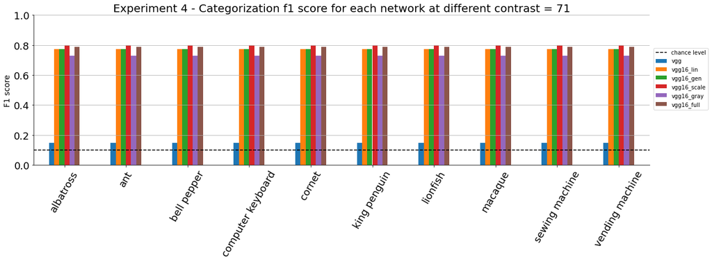

```
--------------------------
Benchmarking contrast = 81
--------------------------
```

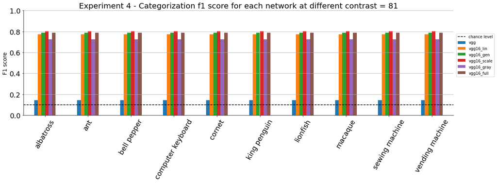

```
--------------------------
Benchmarking contrast = 91
--------------------------
```

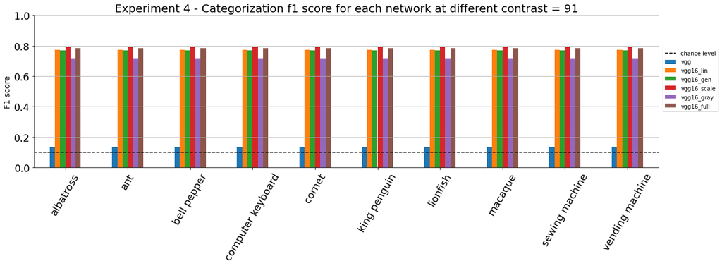

```
---------------------------
Benchmarking contrast = 101
---------------------------
```

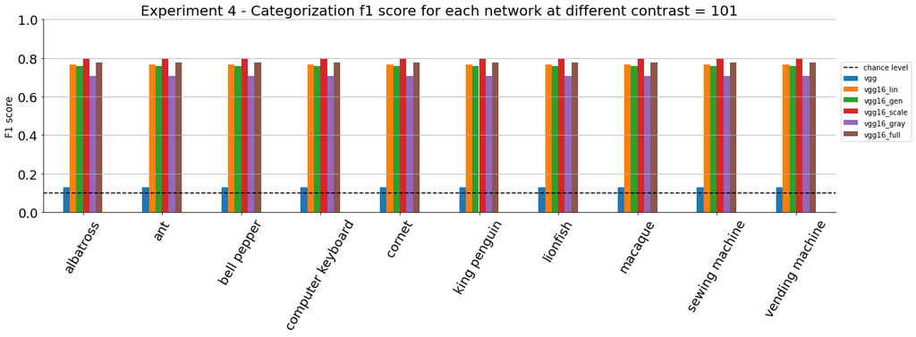

```python
from sklearn.metrics import accuracy_score, precision_score, f1_score
for contrast in np.arange(1,110,10):
    pprint(f'Benchmarking contrast = {contrast}')
    df_acc = pd.DataFrame({model_name: {subset_label: f1_score(df_contrast[(df_contrast['model']==model_name) & (df_contrast['contrast']==contrast)]["top_1"],
                                                               df_contrast[(df_contrast['model']==model_name) & (df_contrast['contrast']==contrast)]["label"],
                                                               average = 'micro')
                                        for subset_label in subset_labels}
                           for model_name in models_vgg.keys()})

    ax = df_acc.plot.bar(rot=60, figsize=(fig_width, fig_width//4), fontsize=18)
    ax.set_ylim(0, 1)
    ax.hlines(xmin=-.5, xmax=len(subset_labels)-.5, y=1/n_output, ls='--', ec='k', label='chance level')
    plt.legend(bbox_to_anchor=(1.1, .35), loc='lower right')
    ax.grid(which='both', axis='y')
    for side in ['top', 'right'] :ax.spines[side].set_visible(False)
    ax.set_title(f'Experiment 4 - Categorization f1 score for each network at different contrast = {contrast}', size=20)
    ax.set_ylabel('F1 score', size=14)
    plt.show();
```

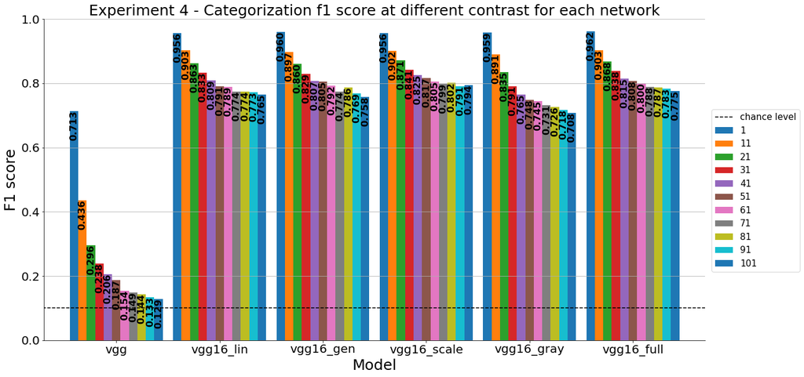

```python
df_acc = pd.DataFrame({model_name: {contrast: f1_score(df_contrast[(df_contrast['model']==model_name) & (df_contrast['contrast']==contrast)]["top_1"],
                                                         df_contrast[(df_contrast['model']==model_name) & (df_contrast['contrast']==contrast)]["label"],
                                                         average='micro')
                                    for contrast in np.arange(1,110,10)}
                       for model_name in models_vgg.keys()})

ax = df_acc.T.plot.bar(rot=0, figsize=(fig_width, fig_width/2), fontsize=20, width=.9)
ax.set_ylim(0, 1)
ax.hlines(xmin=-4.5, xmax=len(models_vgg.keys())+4.5, y=1/n_output, ls='--', ec='k', label='chance level')
# https://matplotlib.org/stable/gallery/lines_bars_and_markers/bar_label_demo.html
for container in ax.containers: ax.bar_label(container, padding=-50, color='black', fontsize=16, fmt='%.3f', rotation=90,fontweight='bold')
plt.legend(bbox_to_anchor=(1.15, .2), loc='lower right', fontsize = 15)
ax.grid(which='both', axis='y')
for side in ['top', 'right'] :ax.spines[side].set_visible(False)
ax.set_title(f'Experiment 4 - Categorization f1 score at different contrast for each network', size=25)
ax.set_ylabel('F1 score', size=25)
ax.set_xlabel('Model', size=25)
plt.show();
```

### Computation time

As there is no big difference for the models, in order to have a clearer display, we chose to expose the characteristics for `VGG_Gen`. Here a display of the differents computation time on the same dataset for different contrast:

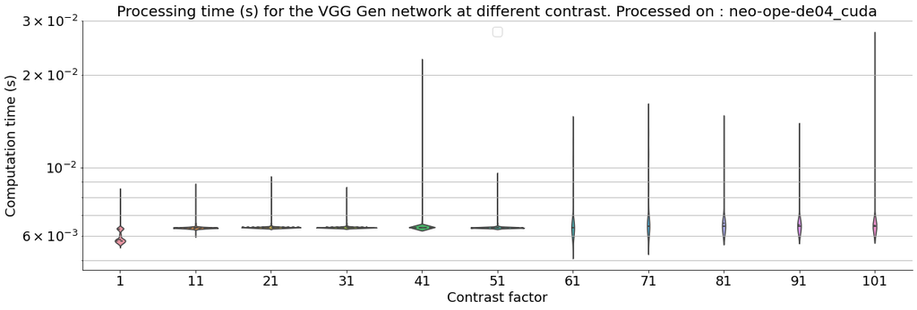

```python
fig, axs = plt.subplots(figsize=(fig_width, fig_width/(phi*2)))
data = df_contrast.loc[df_contrast['model'] == 'vgg16_gen']
axs = sns.violinplot(x="contrast", y="time", data=data, inner="quartile")
axs.set_title('Processing time (s) for the VGG Gen network at different contrast. Processed on : ' + args.HOST + '_' + str(df_contrast['device_type'][0]), size = 20)
axs.set_ylabel('Computation time (s)', size=18)
axs.set_xlabel('Contrast factor', size=18)
axs.set_yscale('log')
axs.grid(which='both', axis='y')
for side in ['top', 'right'] :axs.spines[side].set_visible(False)
h, l = axs.get_legend_handles_labels()
axs.legend(h[:5], l[:5], loc='upper center', fontsize=16);
```

### Categorization likelihood

Again, in order to have a clearer display, we chose to expose the the categorization likelihood for `VGG_Gen` at different contrast.

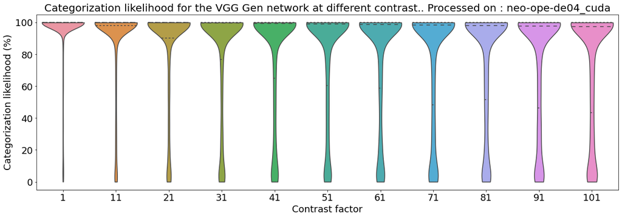

```python
fig, axs = plt.subplots(figsize=(fig_width, fig_width/(phi*2)))
data = df_contrast.loc[df_contrast['model'] == 'vgg16_gen']
axs = sns.violinplot(x="contrast", y="likelihood", data=data, inner="quartile", cut = 0, scale = 'width')
axs.set_title('Categorization likelihood for the VGG Gen network at different contrast.. Processed on : ' + args.HOST + '_' + str(df_contrast['device_type'][0]), size=20)
axs.set_ylabel('Categorization likelihood (%)', size=18)
axs.set_xlabel('Contrast factor', size=18)
ax.grid(which='both', axis='y')
for side in ['top', 'right'] :ax.spines[side].set_visible(False)
h, l = axs.get_legend_handles_labels();
```

### Summary

All network's F1 score are affected by changing the contrast. However, as in experiment 3, the performance remains largely above the chance level, and this for all the re-trained networks, this distinction may from the fact that they were re-trained with a contrast transformation, which shows that our training process partly compensated the degradation of the input's images.

Mean f1 score

```python
for model_name in models_vgg.keys():
    pprint(f'Benchmarking model {model_name}')
    for contrast in np.arange(1,110,10):
        df_ = df_contrast[(df_contrast['model']==model_name) & (df_contrast['contrast']==contrast)]
        mean_f1_score = f1_score(df_["top_1"] , df_["label"] , average = 'micro')
        print(f'For contrast factor {contrast}, the mean f1 score = {mean_f1_score*100:.4f} %' )
```

```
----------------------
Benchmarking model vgg
----------------------
For contrast factor 1, the mean f1 score = 71.2644 %
For contrast factor 11, the mean f1 score = 43.5782 %
For contrast factor 21, the mean f1 score = 29.5602 %
For contrast factor 31, the mean f1 score = 23.8131 %
For contrast factor 41, the mean f1 score = 20.6397 %
For contrast factor 51, the mean f1 score = 18.7156 %
For contrast factor 61, the mean f1 score = 15.4423 %
For contrast factor 71, the mean f1 score = 14.8926 %
For contrast factor 81, the mean f1 score = 14.3928 %
For contrast factor 91, the mean f1 score = 13.3433 %
For contrast factor 101, the mean f1 score = 12.8936 %
----------------------------
Benchmarking model vgg16_lin
----------------------------
For contrast factor 1, the mean f1 score = 95.6272 %
For contrast factor 11, the mean f1 score = 90.3298 %
For contrast factor 21, the mean f1 score = 86.3068 %
For contrast factor 31, the mean f1 score = 83.2584 %
For contrast factor 41, the mean f1 score = 80.9095 %
For contrast factor 51, the mean f1 score = 79.0855 %
For contrast factor 61, the mean f1 score = 78.8856 %
For contrast factor 71, the mean f1 score = 77.4363 %
For contrast factor 81, the mean f1 score = 77.3863 %
For contrast factor 91, the mean f1 score = 77.2614 %
For contrast factor 101, the mean f1 score = 76.5367 %
----------------------------
Benchmarking model vgg16_gen
----------------------------
For contrast factor 1, the mean f1 score = 95.9770 %
For contrast factor 11, the mean f1 score = 89.6802 %
For contrast factor 21, the mean f1 score = 86.0070 %
For contrast factor 31, the mean f1 score = 82.8586 %
For contrast factor 41, the mean f1 score = 80.6597 %
For contrast factor 51, the mean f1 score = 80.5347 %
For contrast factor 61, the mean f1 score = 79.2104 %
For contrast factor 71, the mean f1 score = 77.3613 %
For contrast factor 81, the mean f1 score = 78.6357 %
```

[output cut: 29 more lines]

```
For contrast factor 101, the mean f1 score = 70.7646 %
-----------------------------
Benchmarking model vgg16_full
-----------------------------
For contrast factor 1, the mean f1 score = 96.1769 %
For contrast factor 11, the mean f1 score = 90.2549 %
For contrast factor 21, the mean f1 score = 86.8066 %
For contrast factor 31, the mean f1 score = 83.8081 %
For contrast factor 41, the mean f1 score = 81.4843 %
For contrast factor 51, the mean f1 score = 80.8096 %
For contrast factor 61, the mean f1 score = 80.0350 %
For contrast factor 71, the mean f1 score = 78.8356 %
For contrast factor 81, the mean f1 score = 78.6607 %
For contrast factor 91, the mean f1 score = 78.2609 %
For contrast factor 101, the mean f1 score = 77.5112 %
```

Mean categorization likelihood

```python
for model_name in models_vgg.keys():
    pprint(f'Benchmarking model {model_name}')
    for contrast in np.arange(1,110,10):
        med_likelihood = np.mean(df_contrast[(df_contrast['model']==model_name) & (df_contrast['contrast']==contrast)]["likelihood"])
        print(f'For contrast factor {contrast}, the mean clasification likelihood = {med_likelihood:.5f} %' )
```

```
----------------------
Benchmarking model vgg
----------------------
For contrast factor 1, the mean clasification likelihood = 93.42450 %
For contrast factor 11, the mean clasification likelihood = 78.65400 %
For contrast factor 21, the mean clasification likelihood = 68.43755 %
For contrast factor 31, the mean clasification likelihood = 61.33069 %
For contrast factor 41, the mean clasification likelihood = 58.24161 %
For contrast factor 51, the mean clasification likelihood = 55.11642 %
For contrast factor 61, the mean clasification likelihood = 53.10443 %
For contrast factor 71, the mean clasification likelihood = 52.19755 %
For contrast factor 81, the mean clasification likelihood = 51.43817 %
For contrast factor 91, the mean clasification likelihood = 50.23643 %
For contrast factor 101, the mean clasification likelihood = 49.22434 %
----------------------------
Benchmarking model vgg16_lin
----------------------------
For contrast factor 1, the mean clasification likelihood = 95.00309 %
For contrast factor 11, the mean clasification likelihood = 88.55016 %
For contrast factor 21, the mean clasification likelihood = 83.98296 %
For contrast factor 31, the mean clasification likelihood = 80.66875 %
For contrast factor 41, the mean clasification likelihood = 78.24489 %
For contrast factor 51, the mean clasification likelihood = 76.74437 %
For contrast factor 61, the mean clasification likelihood = 75.91672 %
For contrast factor 71, the mean clasification likelihood = 74.48677 %
For contrast factor 81, the mean clasification likelihood = 74.11826 %
For contrast factor 91, the mean clasification likelihood = 73.70028 %
For contrast factor 101, the mean clasification likelihood = 73.11205 %
----------------------------
Benchmarking model vgg16_gen
----------------------------
For contrast factor 1, the mean clasification likelihood = 94.80409 %
For contrast factor 11, the mean clasification likelihood = 88.36317 %
For contrast factor 21, the mean clasification likelihood = 83.94363 %
For contrast factor 31, the mean clasification likelihood = 80.24268 %
For contrast factor 41, the mean clasification likelihood = 77.85029 %
For contrast factor 51, the mean clasification likelihood = 76.93702 %
For contrast factor 61, the mean clasification likelihood = 76.04521 %
For contrast factor 71, the mean clasification likelihood = 74.03292 %
For contrast factor 81, the mean clasification likelihood = 74.58919 %
```

[output cut: 29 more lines]

```
For contrast factor 101, the mean clasification likelihood = 67.40389 %
-----------------------------
Benchmarking model vgg16_full
-----------------------------
For contrast factor 1, the mean clasification likelihood = 94.99972 %
For contrast factor 11, the mean clasification likelihood = 88.72732 %
For contrast factor 21, the mean clasification likelihood = 84.30309 %
For contrast factor 31, the mean clasification likelihood = 80.99912 %
For contrast factor 41, the mean clasification likelihood = 78.90924 %
For contrast factor 51, the mean clasification likelihood = 77.63452 %
For contrast factor 61, the mean clasification likelihood = 76.75700 %
For contrast factor 71, the mean clasification likelihood = 75.57893 %
For contrast factor 81, the mean clasification likelihood = 75.50289 %
For contrast factor 91, the mean clasification likelihood = 74.71195 %
For contrast factor 101, the mean clasification likelihood = 74.13195 %
```